# Uid-variance-analysis

Ben

4/10/2018

UID predicts rational speakers should attempt to produce utterances that are approximately uniform in their information rate. One way of doing this is by providing cues before high-surprisal content. We examine the degree to which RSA models display provide cues before high-suprisal content in [`summary-spring-2018.Rmd`](https://htmlpreview.github.io/?https://github.com/benpeloquin7/rsa-uid/blob/master/project/summary-spring-2018.html). Relatdely, we can examine another measure of smoothness – looking at the degree to which ngram units vary in their surprisal over a discourse. Smaller variance means “smoother” production. We pursue this idea in the current notebook.

Simulate `n` corpora from `noisy-RSA` model of length `n_tokens`. Given a particular string of tokens we can randomly shuffle the UID cues. If part of what RSA is doing is optimizing for smoothness we should see lower variance in ngram surprisals among the `RSA ordering` vs a `random ordering` of cues. For each corpora $i$ of the $n$ simulations we randomly shuffle the UID cues $n_comparison$ times, comparing the average ngram surprisal variance across these simulations.

Run simulations

```
## 1  2  3  4  5  6  7  8  9  10  11  12  13  14  15  16  17  18  19  20  21  22  23  24  25  26  27  28  29  30  31  32  33  34  35  36  37  38  39  40  41  42  43  44  45  46  47  48  49  50
```

# Simulations

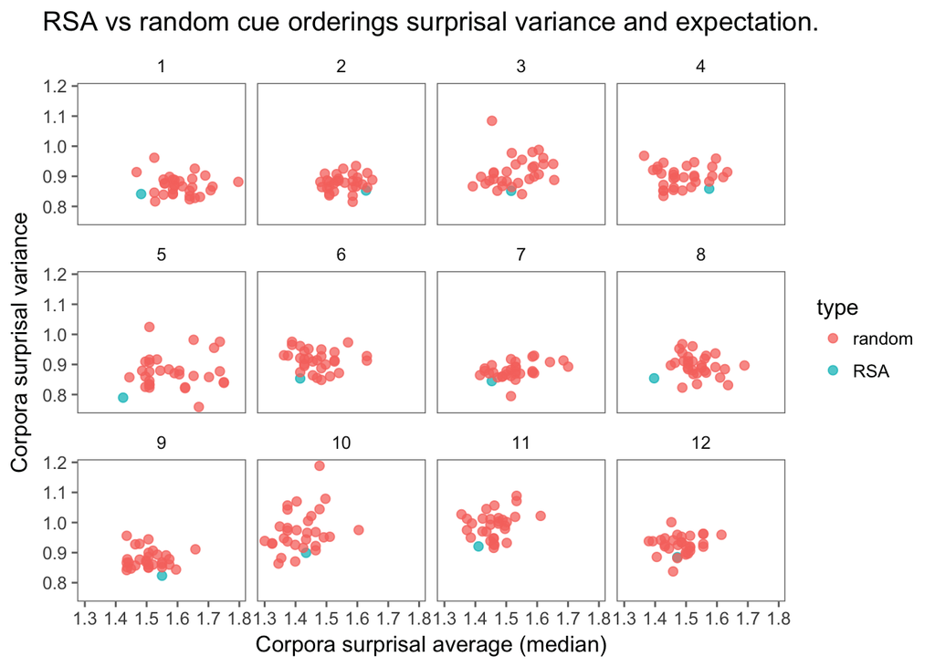

Compare RSA cue ordering variance vs average cue ordering variance for the shuffled models. Again, RSA consistently produces lower variance corpora.

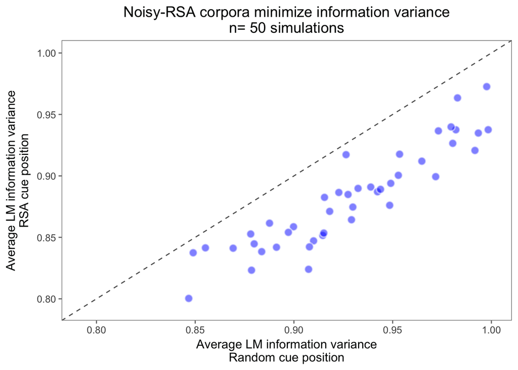

We can test this in a mixed-effects model with `experiment`- and `shuffled number` random effets. We’re interested in whether the type of ordering (`RSA` vs `random`) predicts variance.

`info variance ~ runType (1|experiment) + (1|run number)`

```
## Linear mixed model fit by REML t-tests use Satterthwaite approximations
##   to degrees of freedom [lmerMod]
## Formula: s2Info ~ as.factor(type) + (1 | expNum) + (1 | runNum)
##    Data: dfAllSummary
##
## REML criterion at convergence: -5430.1
##
## Scaled residuals:
##     Min      1Q  Median      3Q     Max
## -4.0657 -0.6040 -0.0845  0.5074  5.5549
##
## Random effects:
##  Groups   Name        Variance  Std.Dev.
##  expNum   (Intercept) 2.856e-03 0.053438
##  runNum   (Intercept) 6.365e-06 0.002523
##  Residual             1.525e-03 0.039054
## Number of obs: 1550, groups:  expNum, 50; runNum, 31
##
## Fixed effects:
##                     Estimate Std. Error        df t value Pr(>|t|)
## (Intercept)         0.934451   0.007638 49.380000  122.34  < 2e-16 ***
## as.factor(type)RSA -0.046109   0.006172 29.000000   -7.47 3.12e-08 ***
## ---
## Signif. codes:  0 '***' 0.001 '**' 0.01 '*' 0.05 '.' 0.1 ' ' 1
##
## Correlation of Fixed Effects:
##             (Intr)
## as.fct()RSA -0.026
```

RSA orderings have typically ~-0.05 bits less variance.